# Tugas APG Pertemuan 5

Bill Van Ricardo Zalukhu

2022-03-16

```r
library('MVN')
library('car')
library('openxlsx')
```

```r
d1 <- effluent_data[, 1] - effluent_data[, 3]
d2 <- effluent_data[, 2] - effluent_data[, 4]
data_delta <- cbind(d1, d2)
```

```r
dbar <- colMeans(data_delta)
dbar
```

```
##        d1        d2
## -9.363636 13.272727
```

```r
sd <- cov(data_delta)
sd
```

```
##           d1        d2
## d1 199.25455  88.30909
## d2  88.30909 418.61818
```

```r
n <- nrow(data_delta)
T2 <- n * t(dbar) %*% solve(sd) %*% dbar
T2
```

```
##          [,1]
## [1,] 13.63931
```

```r
n <- nrow(data_delta)
p <- ncol(data_delta)
alpha <- 0.05

CI <- (((n - 1)*p)/(n - p)) * qf(p = 1 - alpha, df1 = p, df2 = n - p)
CI
```

```
## [1] 9.458877
```

Dari hasil pengujian hipotesis di atas, ternyata nilai $T^{2}$ > $F$, artinya hasilnya adalah `tolak H0`. Oleh karena itu, dapat kita simpulkan bahwa terdapat perbedaan kebutuhan oksigen biokimia dan padatan tersuspend antara lab komersial dan lab dari pemerintah.

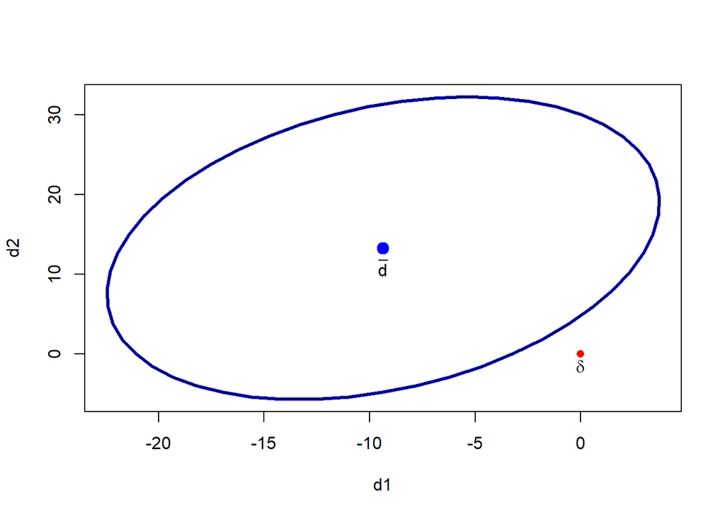

```r
n <- nrow(data_delta)
p <- ncol(data_delta)
Sd <- cov(data_delta)
tconst <- sqrt((p/n)*((n-1)/(n-p)) * qf(1-alpha,p,n-p))
id <- c(1,2)
plot(ellipse(center=dbar[id], shape=Sd[id,id], radius=tconst, draw=F),type="n", xlab="d1", ylab="d2")
lines(ellipse(center=dbar[id], shape=Sd[id,id], radius=tconst, lwd=3), xlab="d1", ylab="d2")
points(0, 0,col="red", pch = 16)
text(0,-1.5,expression(delta))
text(dbar[1],dbar[2]-2.5,expression(bar(d)))
```

Berdasarkan hasil dari penggambaran confidence region ellipsoid dari data, hasilnya ternyata konsisten terhadap hasil uji hipotesisnya. Dalam artian, memang benar, kebutuhan tanaman terhadap oksigen biokimia dan padatan tersuspend yang diuji pada lab komersial berbeda dengan hasil dari lab pemerintah.

```r
bon <- NULL
alpha1 <-1-0.05
alpha2 <-1-(0.05/2)
alpha3 <- 1 - 0.05/(2*2)

for(k in 1:2){
  bon <- c(bon, dbar[k] - sqrt(Sd[k,k]/n) * qt(alpha3, df=n-1), dbar[k] + sqrt(Sd[k,k]/n) * qt(alpha3, df=n-1))
}

rtab <- rbind(bon)
round(rtab, 2)
```

```
##         d1   d1    d2    d2
## bon -20.57 1.85 -2.97 29.52
```

Dari hasil penghitungan confidence interval Bonferoni, ternyata interval nya mengandung nilai 0. Ini mengartikan bahwa terjadi ketidakkonsistenan antara uji hipotesis dan confidence region ellipsoid, dengan hasil dari confidence Bonferoni, yang mengindikasikan ada satu atau semua variabel yang uji hipotesis univariat nya menghasilkan `gagal tolak H0`.

```r
eff_clean <- effluent_data[-c(8), ]
```

```r
dclean1 <- eff_clean[, 1] - eff_clean[, 3]
dclean2 <- eff_clean[, 2] - eff_clean[, 4]
data_clean <- cbind(dclean1, dclean2)
```

```r
dbar_clean <- colMeans(data_clean)
dbar_clean
```

```
## dclean1 dclean2
##   -12.0     8.6
```

```r
sd_clean <- cov(data_clean)
sd_clean
```

```
##           dclean1   dclean2
## dclean1 136.44444 -52.44444
## dclean2 -52.44444 198.26667
```

```r
n_clean <- nrow(data_clean)
T2_clean <- n * t(dbar_clean) %*% solve(sd_clean) %*% dbar_clean
T2_clean
```

```
##          [,1]
## [1,] 12.59117
```

```r
p_clean <- ncol(data_delta)
alpha <- 0.05

CI <- (((n_clean - 1)*p)/(n_clean - p)) * qf(p = 1 - alpha, df1 = p, df2 = n_clean - p)
CI
```

```
## [1] 10.03268
```

Dari hasil pengujian hipotesis terhadap data yang telah dibersihkan dari observasi yang dianggap sebagai outlier pada data, ternyata nilai $T^{2}$ > $F$ (masih sama), artinya hasilnya adalah tetap `tolak H0`. Oleh karena itu, dapat kita simpulkan bahwa terdapat perbedaan kebutuhan oksigen biokimia dan padatan tersuspend antara lab komersial dan lab dari pemerintah, baik sebelum maupun sesudah observasi yang dianggap outlier dihilangkan.

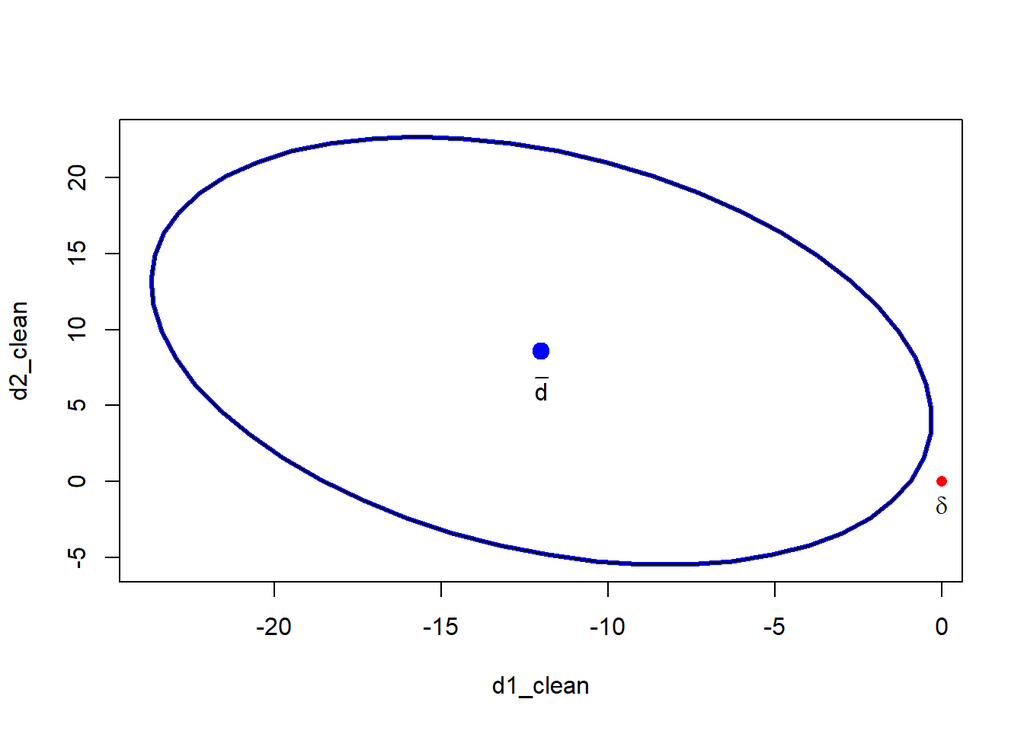

```r
n <- nrow(data_clean)
p <- ncol(data_clean)
Sd_clean <- cov(data_clean)
tconst_clean <- sqrt((p/n)*((n-1)/(n-p)) * qf(1-alpha,p,n-p))
id <- c(1,2)
plot(ellipse(center=dbar_clean[id], shape=Sd_clean[id,id], radius=tconst_clean, draw=F),type="n", xlab="d1_clean", ylab="d2_clean")
lines(ellipse(center=dbar_clean[id], shape=Sd_clean[id,id], radius=tconst_clean, lwd=3), xlab="d1_clean", ylab="d2_clean")
points(0, 0,col="red", pch = 16)
text(0,-1.5,expression(delta))
text(dbar_clean[1],dbar_clean[2]-2.5,expression(bar(d)))
```

Dari hasil confidence region ellipsoidnya, juga menunjukan hasil yang sama dengan yang sebelumnya, yaitu area delta masih berada di luar area penerimaan hipotesis. Artinya adalah hasil dari confidence region, baik sebelum maupun sesudah observasi yang dianggap outlier dihilangkan, masih menghasilkan tolak H0.

```r
bon <- NULL
alpha3 <- 1 - 0.05/(2*p)

for(k in 1:2){
  bon <- c(bon, dbar_clean[k] - sqrt(Sd_clean[k,k]/n_clean) * qt(alpha3, df=n_clean-1), dbar_clean[k] + sqrt(Sd_clean[k,k]/n_clean) * qt(alpha3, df=n_clean-1))
}

rtab <- rbind(bon)
round(rtab, 2)
```

```
##     dclean1 dclean1 dclean2 dclean2
## bon  -21.92   -2.08   -3.36   20.56
```

Dari hasil Bonferoni, ternyata ada satu variabel selisih yang interval nya masih mengandung 0, yaitu variabel selisih padatan tersuspensi, sedangkan variabel yang berkorespondensi dengan hasil pengujian hipotesis sebelumnya yaitu variabel selish oksigen biokimia (dalam artian bahwa ada perbedaan kebutuhan oksigen biokimia antara tempat pengujian tanaman komersial dengan tempat pengujian miliki pemerintah).

```r
eff_tf <- log(effluent_data)
eff_tf
```

```
##       clab_bod  clab_ss slab_bod  slab_ss
##  [1,] 1.791759 3.295837 3.218876 2.708050
##  [2,] 1.791759 3.135494 3.332205 2.564949
##  [3,] 2.890372 4.158883 3.583519 3.091042
##  [4,] 2.079442 3.784190 3.555348 3.367296
##  [5,] 2.397895 3.401197 2.708050 3.433987
##  [6,] 3.526361 4.317488 3.784190 4.158883
##  [7,] 3.332205 3.258097 3.737670 3.401197
##  [8,] 4.262680 4.820282 3.988984 4.158883
##  [9,] 3.761200 3.988984 3.526361 4.025352
## [10,] 3.496508 3.401197 3.367296 2.995732
## [11,] 2.995732 2.639057 3.663562 3.044522
```

```r
dTf1 <- eff_tf[, 1] - eff_tf[, 3]
dTf2 <- eff_tf[, 2] - eff_tf[, 4]
data_transform <- cbind(dTf1, dTf2)
```

```r
dbar_tf <- colMeans(data_transform)
dbar_tf
```

```
##       dTf1       dTf2
## -0.5581951  0.2955283
```

```r
sd_tf <- cov(data_transform)
sd_tf
```

```
##             dTf1        dTf2
## dTf1  0.45608099 -0.07356599
## dTf2 -0.07356599  0.18386750
```

```r
n_tf <- nrow(data_delta)
T2_tf <- n_tf * t(dbar_tf) %*% solve(sd_tf) %*% dbar_tf
T2_tf
```

```
##          [,1]
## [1,] 10.21541
```

```r
p_tf <- ncol(data_transform)
alpha <- 0.05

CI_tf <- (((n_tf - 1)*p_tf)/(n_tf - p_tf)) * qf(p = 1 - alpha, df1 = p_tf, df2 = n_tf - p_tf)
CI_tf
```

```
## [1] 9.458877
```

Dari hasil pengujian hipotesis untuk data yang telah ditransform, ternyata nilai $T^{2}$ > $F$, artinya hasilnya tetap `tolak H0`. Dapat kita simpulkan bahwa data tetap menghasilkan tolak H0 bahkan setelah ditranformasi.

```r
T.ci <- function(mu, Sigma, n, avec=rep(1,length(mu)), level=0.95){
  p <- length(mu)
  if(nrow(Sigma)!=p) stop("Need length(mu) == nrow(Sigma).")
  if(ncol(Sigma)!=p) stop("Need length(mu) == ncol(Sigma).")
  if(length(avec)!=p) stop("Need length(mu) == length(avec).")
  if(level <=0 | level >= 1) stop("Need 0 < level < 1.")
  cval <- qf(level, p, n-p) * p * (n-1) / (n-p)
  zhat <- crossprod(avec, mu)
  zvar <- crossprod(avec, Sigma %*% avec) / n
  const <- sqrt(cval * zvar)
  c(lower = zhat - const, upper = zhat + const) }
S<-cov(eff_tf)
n <- nrow(eff_tf)
p <- ncol(eff_tf)
T.ci(mu=dbar_tf, Sigma=sd_tf, n=n_tf, avec=c(1,0))
```

```
##      lower      upper
## -1.1844404  0.0680501
```

```r
T.ci(mu=dbar_tf, Sigma=sd_tf, n=n_tf, avec=c(0,1))
```

```
##      lower      upper
## -0.1020988  0.6931554
```

Ternyata, jika menggunakan simultaneous confidence interval, semua selangnya mengandung 0, artinya hasil keputusannya adalah gagal tolak H0, bertolak belakang dengna hasil pengujian hipotesis nya yang menghasilkan tolak H0.

```r
bon <- NULL
alpha1 <-1-0.05
alpha2 <-1-(0.05/2)
alpha3 <- 1 - 0.05/(2*2)

for(k in 1:2){
  bon <- c(bon, dbar_tf[k] - sqrt(sd_tf[k,k]/n_tf) * qt(alpha3, df=n_tf-1), dbar_tf[k] + sqrt(sd_tf[k,k]/n_tf) * qt(alpha3, df=n_tf-1))
}

rtab <- rbind(bon)
round(rtab, 2)
```

```
##      dTf1  dTf1  dTf2 dTf2
## bon -1.09 -0.02 -0.04 0.64
```

Dari hasil confidence Bonferoni, ternyata bahkan setelah ditransformasi pun, masih ada variabel yang intervalnya mengandung 0 dan variabelnya masih sama, yaitu variabel selisih kabutuhan padatan tersuspensi, sedangkan unutuk variabel selisih kebutuhan oksigen biokimia masih konsisten dengan hasil uji hipotesisnya (tidak mengandung 0).

- Mardia Test

```r
mvn(data_transform, mvnTest = 'mardia')
```

```
## $multivariateNormality
##              Test         Statistic           p value Result
## 1 Mardia Skewness  1.13687663334458 0.888378049549112    YES
## 2 Mardia Kurtosis -1.20311931548243 0.228930151787021    YES
## 3             MVN              <NA>              <NA>    YES
##
## $univariateNormality
##               Test  Variable Statistic   p value Normality
## 1 Anderson-Darling   dTf1       0.4334    0.2457    YES
## 2 Anderson-Darling   dTf2       0.2185    0.7846    YES
##
## $Descriptives
##       n       Mean   Std.Dev     Median        Min       Max        25th
## dTf1 11 -0.5581951 0.6753377 -0.4054651 -1.5404450 0.2736958 -1.06013177
## dTf2 11  0.2955283 0.4287977  0.4054651 -0.4054651 1.0678406 -0.03457873
##             75th        Skew  Kurtosis
## dTf1 -0.06430869 -0.27603255 -1.548630
## dTf2  0.57916576  0.06358445 -1.145485
```

- Henze-Zikler Test

```r
mvn(data_transform)
```

```
## $multivariateNormality
##            Test        HZ   p value MVN
## 1 Henze-Zirkler 0.4805169 0.1701703 YES
##
## $univariateNormality
##               Test  Variable Statistic   p value Normality
## 1 Anderson-Darling   dTf1       0.4334    0.2457    YES
## 2 Anderson-Darling   dTf2       0.2185    0.7846    YES
##
## $Descriptives
##       n       Mean   Std.Dev     Median        Min       Max        25th
## dTf1 11 -0.5581951 0.6753377 -0.4054651 -1.5404450 0.2736958 -1.06013177
## dTf2 11  0.2955283 0.4287977  0.4054651 -0.4054651 1.0678406 -0.03457873
##             75th        Skew  Kurtosis
## dTf1 -0.06430869 -0.27603255 -1.548630
## dTf2  0.57916576  0.06358445 -1.145485
```

- Royston

```r
mvn(data_transform, mvnTest = 'royston')
```

```
## $multivariateNormality
##      Test        H   p value MVN
## 1 Royston 1.873695 0.3908991 YES
##
## $univariateNormality
##               Test  Variable Statistic   p value Normality
## 1 Anderson-Darling   dTf1       0.4334    0.2457    YES
## 2 Anderson-Darling   dTf2       0.2185    0.7846    YES
##
## $Descriptives
##       n       Mean   Std.Dev     Median        Min       Max        25th
## dTf1 11 -0.5581951 0.6753377 -0.4054651 -1.5404450 0.2736958 -1.06013177
## dTf2 11  0.2955283 0.4287977  0.4054651 -0.4054651 1.0678406 -0.03457873
##             75th        Skew  Kurtosis
## dTf1 -0.06430869 -0.27603255 -1.548630
## dTf2  0.57916576  0.06358445 -1.145485
```

- E-Statistics Test

```r
mvn(data_transform, mvnTest = 'energy')
```

```
## $multivariateNormality
##          Test Statistic p value MVN
## 1 E-statistic 0.7375487   0.205 YES
##
## $univariateNormality
##               Test  Variable Statistic   p value Normality
## 1 Anderson-Darling   dTf1       0.4334    0.2457    YES
## 2 Anderson-Darling   dTf2       0.2185    0.7846    YES
##
## $Descriptives
##       n       Mean   Std.Dev     Median        Min       Max        25th
## dTf1 11 -0.5581951 0.6753377 -0.4054651 -1.5404450 0.2736958 -1.06013177
## dTf2 11  0.2955283 0.4287977  0.4054651 -0.4054651 1.0678406 -0.03457873
##             75th        Skew  Kurtosis
## dTf1 -0.06430869 -0.27603255 -1.548630
## dTf2  0.57916576  0.06358445 -1.145485
```

Dari semua uji yang dilakukan terhadap data selisih dari hasil transformasi, semua uji menyimpulkan bahwa data `berdistribusi multivariat normal`. Artinya, tidak ada pelanggarang kenormalan dari data selisih terhadap data yang telah ditransformasi.

```r
word_arabic <- read.xlsx("C://Users//bilva//OneDrive//Documents//3SI1//Semester 6//Analisis Peubah Ganda//Tugas5 APG-221911069-3SI1-Bill Van Ricardo Zalukhu//Word_Arabic.xlsx")
```

1. Beberapa pernyataan kontras yang bisa didefinisikan dari kasus pada data percobaan antara lain:
- ($\mu_{3}$ + $\mu_{4}$) - ($\mu_{1}$ + $\mu_{2}$) -> kontras terhadap format dari tulisan
- ($\mu_{1}$ + $\mu_{3}$) - ($\mu_{2}$ + $\mu_{4}$) -> kontras terhadap parity
- ($\mu_{1}$ + $\mu_{4}$) - ($\mu_{2}$ + $\mu_{3}$) -> kontras terhadap interaksi antar format tulisan dan parity

```r
treatment1 <- c(-1,-1,1,1)
treatment2 <- c(1,-1,1,-1)
treatment3 <- c(1,-1,-1,1)
C <- rbind(treatment1, treatment2, treatment3)
```

```r
xbar <- colMeans(word_arabic)
xbar
```

```
##   WordDiff   WordSame ArabicDiff ArabicSame
##   967.5625   875.6094   825.3125   710.9375
```

```r
S <- cov(word_arabic)
```

```r
n <- nrow(word_arabic)
T2 <- n * t(C %*% xbar) %*% solve(C %*% S %*% t(C)) %*% (C %*% xbar)
T2
```

```
##          [,1]
## [1,] 153.7275
```

```r
q <- ncol(word_arabic)

alpha <- 0.05

CI <- (((n - 1)*(q - 1))/(n - q + 1)) * qf(p = 1 - alpha, df1 = q - 1, df2 = n - q + 1)
CI
```

```
## [1] 9.40913
```

Terlihat bahwa nilai dari $T^{2}$ > nilai $F$ nya. Hal ini menunjukan bahwa terdapat perbedaan efek dari keempat treatment yang diberikan kepada sampel untuk merespon antara format penulisan huruf dengan format Arabic.

```r
sim <- NULL
alpha3 <- 1 - 0.05

sim1 <- c(sim,
          ((xbar[3] + xbar[4]) - (xbar[1] + xbar[2])) - sqrt((t(C[1, ]) %*% S %*% C[1, ])/n) * sqrt((((n - 1)*(q - 1))/(n - q + 1)) * qf(p = alpha3, df1 = q - 1, df2 = n - q + 1)),
          ((xbar[3] + xbar[4]) - (xbar[1] + xbar[2])) + sqrt((t(C[1, ]) %*% S %*% C[1, ])/n) * sqrt((((n - 1)*(q - 1))/(n - q + 1)) * qf(p = alpha3, df1 = q - 1, df2 = n - q + 1)))

sim2 <- c(sim,
          ((xbar[1] + xbar[3]) - (xbar[2] + xbar[4])) - sqrt((t(C[2, ]) %*% S %*% C[2, ])/n) * sqrt((((n - 1)*(q - 1))/(n - q + 1)) * qf(p = alpha3, df1 = q - 1, df2 = n - q + 1)),
          ((xbar[1] + xbar[3]) - (xbar[2] + xbar[4])) + sqrt((t(C[2, ]) %*% S %*% C[2, ])/n) * sqrt((((n - 1)*(q - 1))/(n - q + 1)) * qf(p = alpha3, df1 = q - 1, df2 = n - q + 1)))

sim3 <- c(sim,
          ((xbar[1] + xbar[4]) - (xbar[2] + xbar[3])) - sqrt((t(C[3, ]) %*% S %*% C[3, ])/n) * sqrt((((n - 1)*(q - 1))/(n - q + 1)) * qf(p = alpha3, df1 = q - 1, df2 = n - q + 1)),
          ((xbar[1] + xbar[4]) - (xbar[2] + xbar[3])) + sqrt((t(C[3, ]) %*% S %*% C[3, ])/n) * sqrt((((n - 1)*(q - 1))/(n - q + 1)) * qf(p = alpha3, df1 = q - 1, df2 = n - q + 1)))

rtab <- rbind(sim1, sim2, sim3)
round(rtab, 2)
```

```
##         [,1]    [,2]
## sim1 -415.74 -198.11
## sim2  130.46  282.20
## sim3  -76.67   31.82
```

```r
bon <- NULL
alpha3_bon <- 1 - (0.05/2 * (q - 1))

bon1 <- c(bon,
          ((xbar[3] + xbar[4]) - (xbar[1] + xbar[2])) - sqrt((t(C[1, ]) %*% S %*% C[1, ])/n) * qt(alpha3_bon, df = n - 1),
          ((xbar[3] + xbar[4]) - (xbar[1] + xbar[2])) + sqrt((t(C[1, ]) %*% S %*% C[1, ])/n) * qt(alpha3_bon, df = n-1))

bon2 <- c(bon,
          ((xbar[1] + xbar[3]) - (xbar[2] + xbar[4])) - sqrt((t(C[2, ]) %*% S %*% C[2, ])/n) * qt(alpha3_bon, df = n - 1),
          ((xbar[1] + xbar[3]) - (xbar[2] + xbar[4])) + sqrt((t(C[2, ]) %*% S %*% C[2, ])/n) * qt(alpha3_bon, df = n - 1))

bon3 <- c(bon,
          ((xbar[1] + xbar[4]) - (xbar[2] + xbar[3])) - sqrt((t(C[3, ]) %*% S %*% C[3, ])/n) * qt(alpha3_bon, df = n - 1),
          ((xbar[1] + xbar[4]) - (xbar[2] + xbar[3])) + sqrt((t(C[3, ]) %*% S %*% C[3, ])/n) * qt(alpha3_bon, df = n-1))

rtab <- rbind(bon1, bon2, bon3)
round(rtab, 2)
```

```
##         [,1]    [,2]
## bon1 -359.29 -254.56
## bon2  169.82  242.84
## bon3  -48.53    3.68
```

Jika kita bandingkan antar hasil simultaneous confidence interval dan Bonferoni confidence interval, dapat kita lihat hasilnya memiliki bentuk selang yang sama, dimana selang untuk kontras pertama dan kedua itu konsisten terhadap hasil pengujiannya (tolak H0), sedangkan selang untuk kontras ketiga nya mengandung 0, tidak konsisten terhadap hasil pengujian hipotesis nya (gagal tolak H0). Dapat disimpulkan bahwa tidak ada interaksi yang terjadi antartreatment yang diberikan kepada sampel yang diberi pengujian.

Jika melihat dari hasil pengujian simultaneous confidence interval nya, khususnya pada kombinasi kontras atau interval ke tiga, dapat kita melihat bahwa interval nya mengandung 0, artinya tidak ada interaksi yang terjadi antartreatment yang dilakukan, baik tes yang menggunakan kata-kata sebagai pembandingnya, maupun yang menggunakan format Arab. Dengan begitu, dapat kita simpulkan bahwa model yang cocok untuk mendukung tes tersebut adalah model M.

-> Bentuk data pertama

Untuk bentuk data pertama, diperoleh dengan mengalikan data semual dengan setiap vektor kontras yang telah didefinisikan sebelumnya.

```r
wordArabic_matrix <- as.matrix(word_arabic)
format <- wordArabic_matrix %*% C[1, ]
parity <- wordArabic_matrix %*% C[2, ]
interaction <- wordArabic_matrix %*% C[3, ]

construct_score <- cbind(format, parity, interaction)
```

Setelah kita membangung score berdasarkan perkalian antara matriks kontras dengan data awal, kita akan lakukan uji multivariat normal terhadap data tersebut.

- Mardia Test

```r
set.seed(1000)
mvn(construct_score, mvnTest = 'mardia')
```

```
## $multivariateNormality
##              Test        Statistic            p value Result
## 1 Mardia Skewness 19.8907307206908 0.0303032967627702     NO
## 2 Mardia Kurtosis 1.48240196389931  0.138233371738183    YES
## 3             MVN             <NA>               <NA>     NO
##
## $univariateNormality
##               Test  Variable Statistic   p value Normality
## 1 Anderson-Darling  Column1     0.3966    0.3496    YES
## 2 Anderson-Darling  Column2     0.7629    0.0423    NO
## 3 Anderson-Darling  Column3     0.4373    0.2783    YES
##
## $Descriptives
##    n       Mean  Std.Dev  Median    Min   Max    25th     75th       Skew
## 1 32 -306.92188 200.6721 -276.75 -879.5  75.0 -438.50 -192.250 -0.6150826
## 2 32  206.32812 139.9195  169.25  -34.5 607.0  121.25  283.375  0.8980471
## 3 32  -22.42188 100.0367  -37.50 -217.0 229.5  -82.50   29.750  0.3086301
##     Kurtosis
## 1  0.6810366
## 2  0.6024854
## 3 -0.0977505
```

- Henze-Zikler

```r
set.seed(1000)
mvn(construct_score)
```

```
## $multivariateNormality
##            Test      HZ    p value MVN
## 1 Henze-Zirkler 1.02264 0.01106792  NO
##
## $univariateNormality
##               Test  Variable Statistic   p value Normality
## 1 Anderson-Darling  Column1     0.3966    0.3496    YES
## 2 Anderson-Darling  Column2     0.7629    0.0423    NO
## 3 Anderson-Darling  Column3     0.4373    0.2783    YES
##
## $Descriptives
##    n       Mean  Std.Dev  Median    Min   Max    25th     75th       Skew
## 1 32 -306.92188 200.6721 -276.75 -879.5  75.0 -438.50 -192.250 -0.6150826
## 2 32  206.32812 139.9195  169.25  -34.5 607.0  121.25  283.375  0.8980471
## 3 32  -22.42188 100.0367  -37.50 -217.0 229.5  -82.50   29.750  0.3086301
##     Kurtosis
## 1  0.6810366
## 2  0.6024854
## 3 -0.0977505
```

- Royston

```r
set.seed(1000)
mvn(construct_score, mvnTest = 'royston')
```

```
## $multivariateNormality
##      Test        H    p value MVN
## 1 Royston 6.565335 0.07851176 YES
##
## $univariateNormality
##               Test  Variable Statistic   p value Normality
## 1 Anderson-Darling  Column1     0.3966    0.3496    YES
## 2 Anderson-Darling  Column2     0.7629    0.0423    NO
## 3 Anderson-Darling  Column3     0.4373    0.2783    YES
##
## $Descriptives
##    n       Mean  Std.Dev  Median    Min   Max    25th     75th       Skew
## 1 32 -306.92188 200.6721 -276.75 -879.5  75.0 -438.50 -192.250 -0.6150826
## 2 32  206.32812 139.9195  169.25  -34.5 607.0  121.25  283.375  0.8980471
## 3 32  -22.42188 100.0367  -37.50 -217.0 229.5  -82.50   29.750  0.3086301
##     Kurtosis
## 1  0.6810366
## 2  0.6024854
## 3 -0.0977505
```

- E-Statistics

```r
set.seed(1000)
mvn(construct_score, mvnTest = 'energy')
```

```
## $multivariateNormality
##          Test Statistic p value MVN
## 1 E-statistic  1.265676   0.003  NO
##
## $univariateNormality
##               Test  Variable Statistic   p value Normality
## 1 Anderson-Darling  Column1     0.3966    0.3496    YES
## 2 Anderson-Darling  Column2     0.7629    0.0423    NO
## 3 Anderson-Darling  Column3     0.4373    0.2783    YES
##
## $Descriptives
##    n       Mean  Std.Dev  Median    Min   Max    25th     75th       Skew
## 1 32 -306.92188 200.6721 -276.75 -879.5  75.0 -438.50 -192.250 -0.6150826
## 2 32  206.32812 139.9195  169.25  -34.5 607.0  121.25  283.375  0.8980471
## 3 32  -22.42188 100.0367  -37.50 -217.0 229.5  -82.50   29.750  0.3086301
##     Kurtosis
## 1  0.6810366
## 2  0.6024854
## 3 -0.0977505
```

- Mulvariat Shapiro-Wilk

```r
set.seed(1000)
RVAideMemoire::mshapiro.test(construct_score)
```

```
##
##  Multivariate Shapiro-Wilk normality test
##
## data:  ()
## W = 0.86793, p-value = 0.00104
```

Ternyata, berdasarkan uji multivariat normal dari data score hasil perkalian antara kombinasi treatment dengan data semula, hasilnya menunjukan bahwa data score melanggar asumsi kenormalan.

-> Bentuk data kedua

Untuk bentuk data kedua, diperoleh dengan melakukan operasi aritmetik terhadap data awal, mengikuti kombinasi kontras yang telah didefinisikan sebelumnya.

```r
format_2 <- (word_arabic[, 3] + word_arabic[, 4]) - (word_arabic[, 1] + word_arabic[, 2])
parity_2 <- (word_arabic[, 1] + word_arabic[, 3]) - (word_arabic[, 2] + word_arabic[, 4])
interaction_2 <- (word_arabic[, 1] + word_arabic[, 4]) - (word_arabic[, 2] + word_arabic[, 3])
constructScore_2 <- cbind(format_2, parity_2, interaction_2)
constructScore_2
```

```
##       format_2 parity_2 interaction_2
##  [1,]   -437.5     98.5         -81.5
##  [2,]   -533.0    139.0         101.0
##  [3,]   -327.5    132.5         118.5
##  [4,]   -464.0    332.0          12.0
##  [5,]   -249.0    161.0         109.0
##  [6,]     75.0    331.0        -194.0
##  [7,]   -377.0    436.0         116.0
##  [8,]   -879.5    -34.5         229.5
##  [9,]   -265.0    321.0         -39.0
## [10,]   -456.0    252.0          44.0
## [11,]   -154.0    132.0         -28.0
## [12,]   -405.0    279.0        -103.0
## [13,]   -461.5    177.5         -85.5
## [14,]   -106.5    107.5          30.5
```

[output cut: 18 more lines]

- Mardia Test

```r
mvn(constructScore_2, mvnTest = 'mardia')
```

```
## $multivariateNormality
##              Test        Statistic            p value Result
## 1 Mardia Skewness 19.8907307206908 0.0303032967627702     NO
## 2 Mardia Kurtosis 1.48240196389931  0.138233371738183    YES
## 3             MVN             <NA>               <NA>     NO
##
## $univariateNormality
##               Test      Variable Statistic   p value Normality
## 1 Anderson-Darling   format_2       0.3966    0.3496    YES
## 2 Anderson-Darling   parity_2       0.7629    0.0423    NO
## 3 Anderson-Darling interaction_2    0.4373    0.2783    YES
##
## $Descriptives
##                n       Mean  Std.Dev  Median    Min   Max    25th     75th
## format_2      32 -306.92188 200.6721 -276.75 -879.5  75.0 -438.50 -192.250
## parity_2      32  206.32812 139.9195  169.25  -34.5 607.0  121.25  283.375
## interaction_2 32  -22.42188 100.0367  -37.50 -217.0 229.5  -82.50   29.750
##                     Skew   Kurtosis
## format_2      -0.6150826  0.6810366
## parity_2       0.8980471  0.6024854
## interaction_2  0.3086301 -0.0977505
```

- Henze-Zikler

```r
mvn(constructScore_2)
```

```
## $multivariateNormality
##            Test      HZ    p value MVN
## 1 Henze-Zirkler 1.02264 0.01106792  NO
##
## $univariateNormality
##               Test      Variable Statistic   p value Normality
## 1 Anderson-Darling   format_2       0.3966    0.3496    YES
## 2 Anderson-Darling   parity_2       0.7629    0.0423    NO
## 3 Anderson-Darling interaction_2    0.4373    0.2783    YES
##
## $Descriptives
##                n       Mean  Std.Dev  Median    Min   Max    25th     75th
## format_2      32 -306.92188 200.6721 -276.75 -879.5  75.0 -438.50 -192.250
## parity_2      32  206.32812 139.9195  169.25  -34.5 607.0  121.25  283.375
## interaction_2 32  -22.42188 100.0367  -37.50 -217.0 229.5  -82.50   29.750
##                     Skew   Kurtosis
## format_2      -0.6150826  0.6810366
## parity_2       0.8980471  0.6024854
## interaction_2  0.3086301 -0.0977505
```

- Royston

```r
mvn(construct_score, mvnTest = 'royston')
```

```
## $multivariateNormality
##      Test        H    p value MVN
## 1 Royston 6.565335 0.07851176 YES
##
## $univariateNormality
##               Test  Variable Statistic   p value Normality
## 1 Anderson-Darling  Column1     0.3966    0.3496    YES
## 2 Anderson-Darling  Column2     0.7629    0.0423    NO
## 3 Anderson-Darling  Column3     0.4373    0.2783    YES
##
## $Descriptives
##    n       Mean  Std.Dev  Median    Min   Max    25th     75th       Skew
## 1 32 -306.92188 200.6721 -276.75 -879.5  75.0 -438.50 -192.250 -0.6150826
## 2 32  206.32812 139.9195  169.25  -34.5 607.0  121.25  283.375  0.8980471
## 3 32  -22.42188 100.0367  -37.50 -217.0 229.5  -82.50   29.750  0.3086301
##     Kurtosis
## 1  0.6810366
## 2  0.6024854
## 3 -0.0977505
```

- E-Statistics

```r
mvn(construct_score, mvnTest = 'energy')
```

```
## $multivariateNormality
##          Test Statistic p value MVN
## 1 E-statistic  1.265676   0.003  NO
##
## $univariateNormality
##               Test  Variable Statistic   p value Normality
## 1 Anderson-Darling  Column1     0.3966    0.3496    YES
## 2 Anderson-Darling  Column2     0.7629    0.0423    NO
## 3 Anderson-Darling  Column3     0.4373    0.2783    YES
##
## $Descriptives
##    n       Mean  Std.Dev  Median    Min   Max    25th     75th       Skew
## 1 32 -306.92188 200.6721 -276.75 -879.5  75.0 -438.50 -192.250 -0.6150826
## 2 32  206.32812 139.9195  169.25  -34.5 607.0  121.25  283.375  0.8980471
## 3 32  -22.42188 100.0367  -37.50 -217.0 229.5  -82.50   29.750  0.3086301
##     Kurtosis
## 1  0.6810366
## 2  0.6024854
## 3 -0.0977505
```

```r
RVAideMemoire::mshapiro.test(construct_score)
```

```
##
##  Multivariate Shapiro-Wilk normality test
##
## data:  ()
## W = 0.86793, p-value = 0.00104
```